# Modèles VAR & VECM

Martin ADECHI & Serge Gnacadja

2024-06-17

# Modélisation des données stochastiques de séries chronologiques

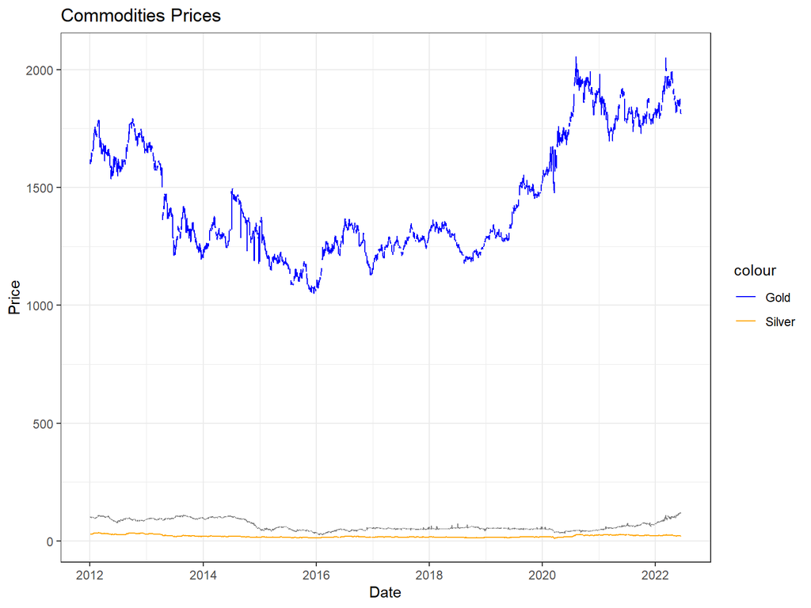

```r
library(ggplot2)

commodities <- read.csv("commodities_12_22.csv")

commodities$Date <- as.Date(commodities$Date)

ggplot(commodities, aes(x = Date)) +
  geom_line(aes(y = Gold, color = "Gold")) +
  geom_line(aes(y = Silver, color = "Silver")) +
  geom_line(aes(y = Crude.Oil, color = "Crude Oil")) +
  labs(x = "Date", y = "Price", title = "Commodities Prices") +
  scale_color_manual(values = c("Gold" = "blue", "Silver" = "orange", "Oil" = "green")) +
  theme_bw()
```

Le **modèle intégré VECTOR auto-régressif (VAR)** comprend plusieurs séries chronologiques et est un outil très utile pour la prévision. Il peut être considéré comme une extension du modèle auto-régressif (partie AR d’ARIMA). Le modèle VAR implique plusieurs variables indépendantes et a donc plus d’une équation. Chaque équation utilise comme variables explicatives des décalages de toutes les variables et probablement une tendance déterministe. Les modèles de séries chronologiques pour VAR sont généralement basés sur l’application de VAR à des séries stationnaires avec des premières différences par rapport aux séries originales et, de ce fait, il existe toujours une possibilité de perte d’informations sur la relation entre les séries intégrées.

Par conséquent, différencier les séries pour les rendre stationnaires est une solution, mais au prix d’ignorer les relations éventuellement importantes ( «à long terme» ) entre les niveaux. Une meilleure solution consiste à tester si les régressions de niveaux sont fiables ( «cointégration» ) . L’approche habituelle consiste à utiliser la méthode de Johansen pour tester si la cointégration existe ou non. Si la réponse est «oui», alors un **modèle de correction d’erreur vectorielle (VECM)** , qui combine les niveaux et les différences, peut être estimé au lieu d’un VAR en niveaux. Nous allons donc vérifier si VECM a réussi à surpasser VAR pour la série que nous avons.

# Chargement de tous les jeux de données (or, argent et pétrole brut)

Voyons voir un peu de quoi il s’agit dans notre dataset.

```r
# Affichage des premières lignes
head(commodities)
```

```
##         Date Crude.Oil Brent.Oil Natural.Gas   Gold Silver Copper
## 1 2022-06-15    119.11    121.35       7.296 1814.8 21.090 4.1777
## 2 2022-06-14    118.93    121.17       7.189 1813.5 20.954 4.1565
## 3 2022-06-13    120.93    122.27       8.609 1831.8 21.255 4.2115
## 4 2022-06-10    120.67    122.01       8.850 1875.5 21.931 4.2945
## 5 2022-06-09    121.51    123.07       8.963 1852.8 21.817 4.3810
## 6 2022-06-08    122.11    123.58       8.699 1856.5 22.094 4.4545
```

```r
# Affichage des dernières lignes
tail(commodities)
```

```
##            Date Crude.Oil Brent.Oil Natural.Gas Gold Silver Copper
## 3254 2012-02-05        NA        NA          NA   NA 33.648     NA
## 3255 2012-01-29        NA        NA          NA   NA 33.908     NA
## 3256 2012-01-22        NA        NA          NA   NA 31.793     NA
## 3257 2012-01-15        NA        NA          NA   NA 29.785     NA
## 3258 2012-01-08        NA        NA          NA   NA 28.848     NA
## 3259 2012-01-02        NA        NA          NA   NA 28.160     NA
```

```r
summary(commodities)
```

```
##       Date              Crude.Oil        Brent.Oil       Natural.Gas
##  Min.   :2012-01-02   Min.   : 26.21   Min.   : 19.33   Min.   :1.482
##  1st Qu.:2014-08-13   1st Qu.: 50.10   1st Qu.: 52.37   1st Qu.:2.582
##  Median :2017-03-27   Median : 55.28   Median : 66.55   Median :2.912
##  Mean   :2017-03-25   Mean   : 65.70   Mean   : 73.71   Mean   :3.174
##  3rd Qu.:2019-11-05   3rd Qu.: 90.03   3rd Qu.:103.46   3rd Qu.:3.649
##  Max.   :2022-06-15   Max.   :122.11   Max.   :127.98   Max.   :9.322
##                       NA's   :525      NA's   :558      NA's   :526
##       Gold          Silver          Copper
##  Min.   :1050   Min.   :11.77   Min.   :1.994
##  1st Qu.:1256   1st Qu.:16.32   1st Qu.:2.688
##  Median :1337   Median :18.07   Median :3.050
##  Mean   :1453   Mean   :20.32   Mean   :3.126
##  3rd Qu.:1685   3rd Qu.:23.90   3rd Qu.:3.435
##  Max.   :2055   Max.   :37.14   Max.   :4.912
##  NA's   :517    NA's   :3       NA's   :573
```

```r
str(commodities)
```

```
## 'data.frame':    3259 obs. of  7 variables:
##  $ Date       : Date, format: "2022-06-15" "2022-06-14" ...
##  $ Crude.Oil  : num  119 119 121 121 122 ...
##  $ Brent.Oil  : num  121 121 122 122 123 ...
##  $ Natural.Gas: num  7.3 7.19 8.61 8.85 8.96 ...
##  $ Gold       : num  1815 1814 1832 1876 1853 ...
##  $ Silver     : num  21.1 21 21.3 21.9 21.8 ...
##  $ Copper     : num  4.18 4.16 4.21 4.29 4.38 ...
```

Selection des variables d’interêt et suppression des lignes contenant des **NA**

```r
df <- data.frame(Date = commodities$Date, Crude.Oil = commodities$Crude.Oil, Gold = commodities$Gold, Silver = commodities$Silver)

df <- na.omit(df)
```

```r
# Affichage des premières lignes
head(df)
```

```
##         Date Crude.Oil   Gold Silver
## 1 2022-06-15    119.11 1814.8 21.090
## 2 2022-06-14    118.93 1813.5 20.954
## 3 2022-06-13    120.93 1831.8 21.255
## 4 2022-06-10    120.67 1875.5 21.931
## 5 2022-06-09    121.51 1852.8 21.817
## 6 2022-06-08    122.11 1856.5 22.094
```

```r
# Affichage des dernières lignes
tail(df)
```

```
##            Date Crude.Oil   Gold Silver
## 2729 2012-01-10    102.24 1631.0 29.783
## 2730 2012-01-09    101.31 1607.5 28.749
## 2731 2012-01-06    101.56 1616.1 28.653
## 2732 2012-01-05    101.81 1619.4 29.265
## 2733 2012-01-04    103.22 1611.9 29.063
## 2734 2012-01-03    102.96 1599.7 29.533
```

```r
summary(df)
```

```
##       Date              Crude.Oil           Gold          Silver
##  Min.   :2012-01-03   Min.   : 26.21   Min.   :1050   Min.   :11.77
##  1st Qu.:2014-09-03   1st Qu.: 50.10   1st Qu.:1256   1st Qu.:16.31
##  Median :2017-04-06   Median : 55.28   Median :1337   Median :18.04
##  Mean   :2017-04-04   Mean   : 65.70   Mean   :1453   Mean   :20.26
##  3rd Qu.:2019-11-08   3rd Qu.: 90.07   3rd Qu.:1684   3rd Qu.:23.80
##  Max.   :2022-06-15   Max.   :122.11   Max.   :2055   Max.   :37.14
```

```r
str(df)
```

```
## 'data.frame':    2732 obs. of  4 variables:
##  $ Date     : Date, format: "2022-06-15" "2022-06-14" ...
##  $ Crude.Oil: num  119 119 121 121 122 ...
##  $ Gold     : num  1815 1814 1832 1876 1853 ...
##  $ Silver   : num  21.1 21 21.3 21.9 21.8 ...
##  - attr(*, "na.action")= 'omit' Named int [1:527] 251 1596 2735 2736 2737 2738 2739 2740 2741 2742 ...
##   ..- attr(*, "names")= chr [1:527] "251" "1596" "2735" "2736" ...
```

Un test rapide consiste à vérifier si les données sont aléatoires. Les données aléatoires ne présenteront pas de structure dans le graphique de décalage.

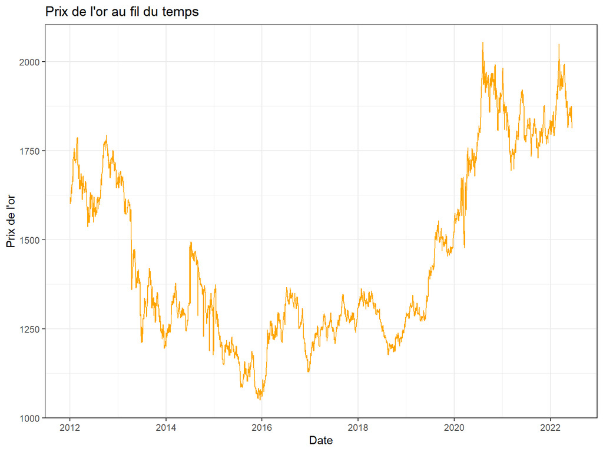

```r
# Installez et chargez les packages nécessaires
#install.packages(c("ggplot2", "dplyr"))
library(ggplot2)
library(dplyr)

# Tracer les séries temporelles
ggplot(df, aes(x = Date, y = Gold)) +
  geom_line(color="orange") +
  labs(title = "Prix de l'or au fil du temps", x = "Date", y = "Prix de l'or") +
  theme_bw()
```

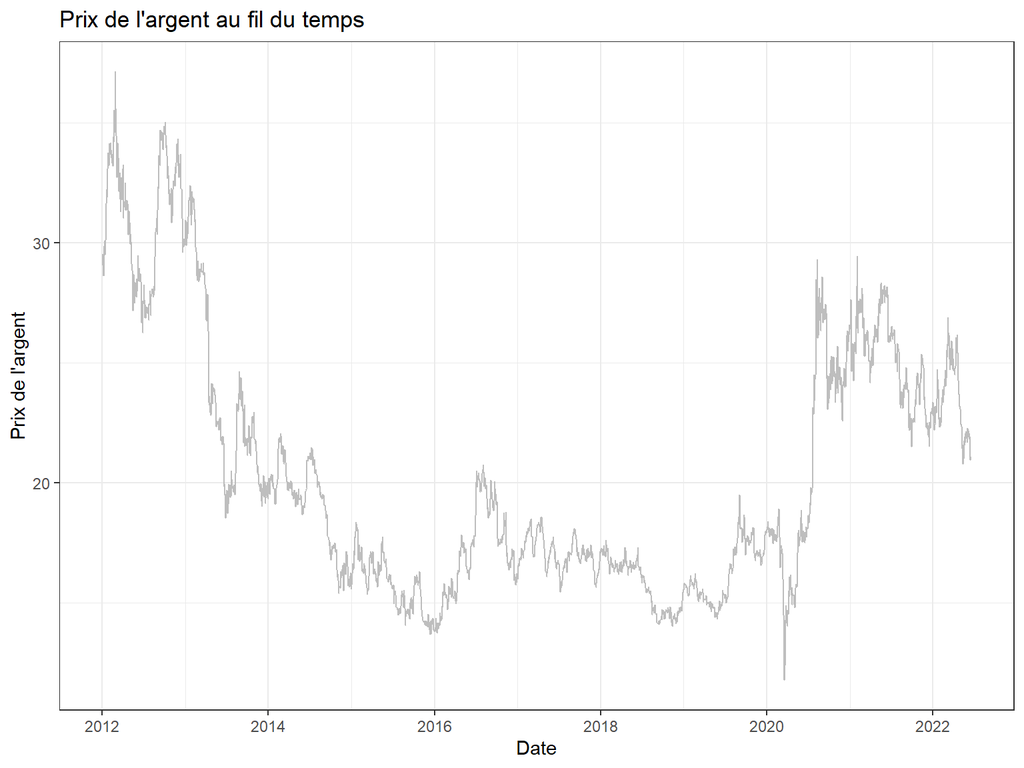

```r
ggplot(df, aes(x = Date, y = Silver)) +
  geom_line(color="grey") +
  labs(title = "Prix de l'argent au fil du temps", x = "Date", y = "Prix de l'argent") +
  theme_bw()
```

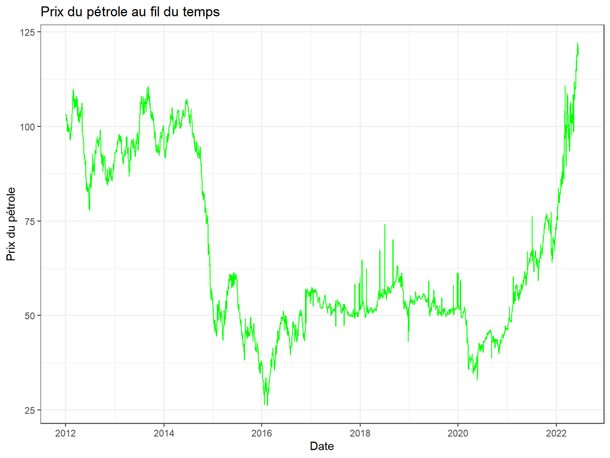

```r
ggplot(df, aes(x = Date, y = Crude.Oil)) +
  geom_line(color="green") +
  labs(title = "Prix du pétrole au fil du temps", x = "Date", y = "Prix du pétrole") +
  theme_bw()
```

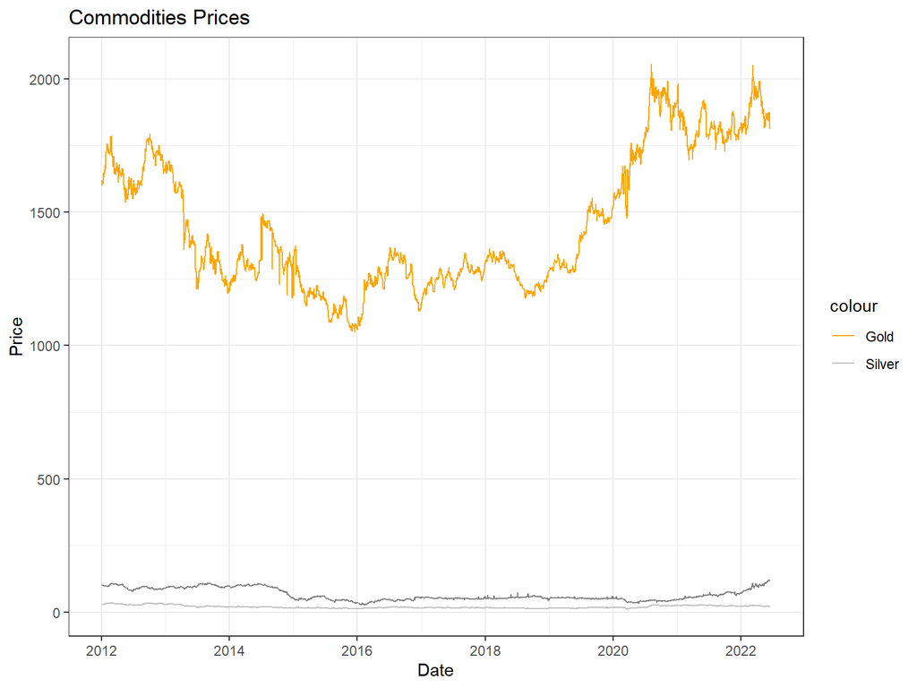

```r
# Mise en Commun
ggplot(df, aes(x=Date))+
  geom_line(aes(y = Gold, color = "Gold")) +
  geom_line(aes(y = Silver, color = "Silver")) +
  geom_line(aes(y = Crude.Oil, color = "Crude Oil")) +
  labs(x = "Date", y = "Price", title = "Commodities Prices") +
  scale_color_manual(values = c("Gold" = "orange", "Silver" = "grey", "Oil" = "green")) +
  theme_bw()
```

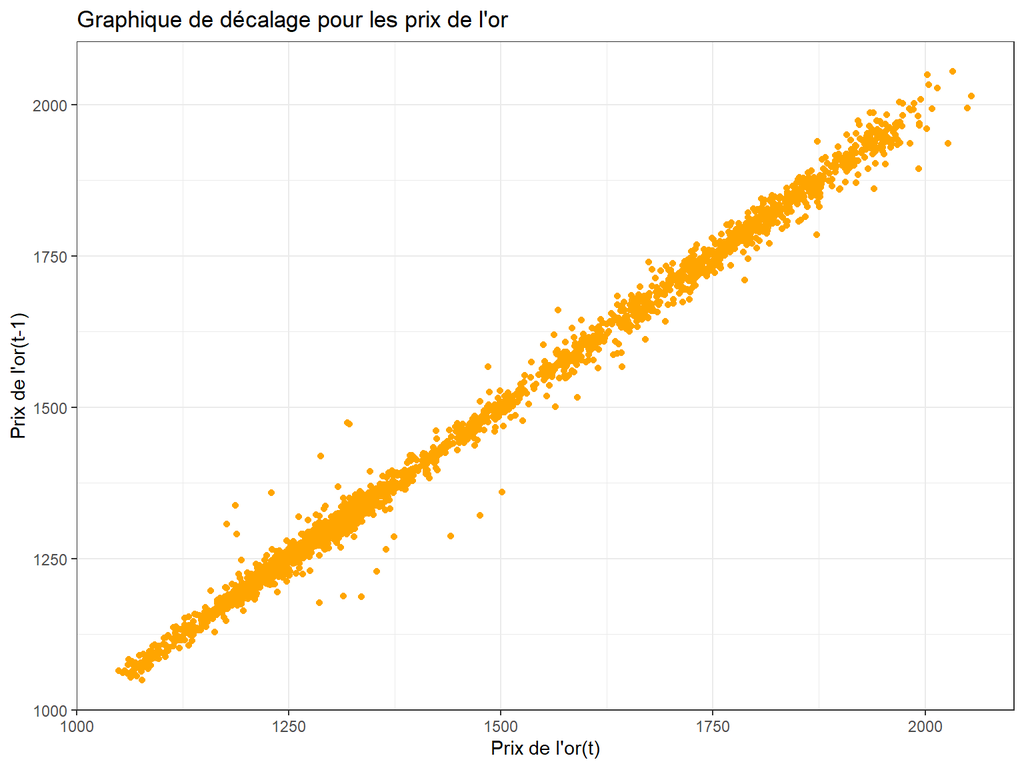

```r
# Créez un graphique de décalage de l'or
ggplot(df, aes(x = Gold, y = lag(Gold, 1))) +
  geom_point(color="orange") +
  labs(title = "Graphique de décalage pour les prix de l'or", x = "Prix de l'or(t)", y = "Prix de l'or(t-1)") +
  theme_bw()
```

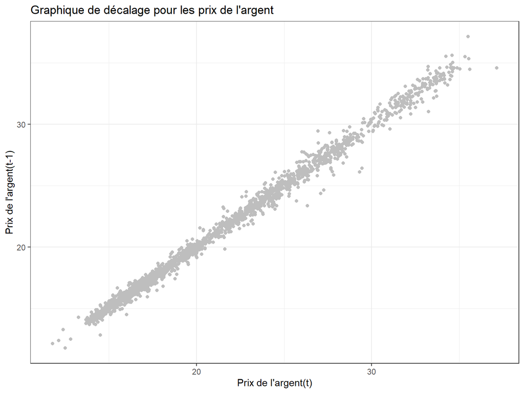

```r
# Créez un graphique de décalage de l'argent
ggplot(df, aes(x = Silver, y = lag(Silver, 1))) +
  geom_point(color="grey") +
  labs(title = "Graphique de décalage pour les prix de l'argent", x = "Prix de l'argent(t)", y = "Prix de l'argent(t-1)") +
  theme_bw()
```

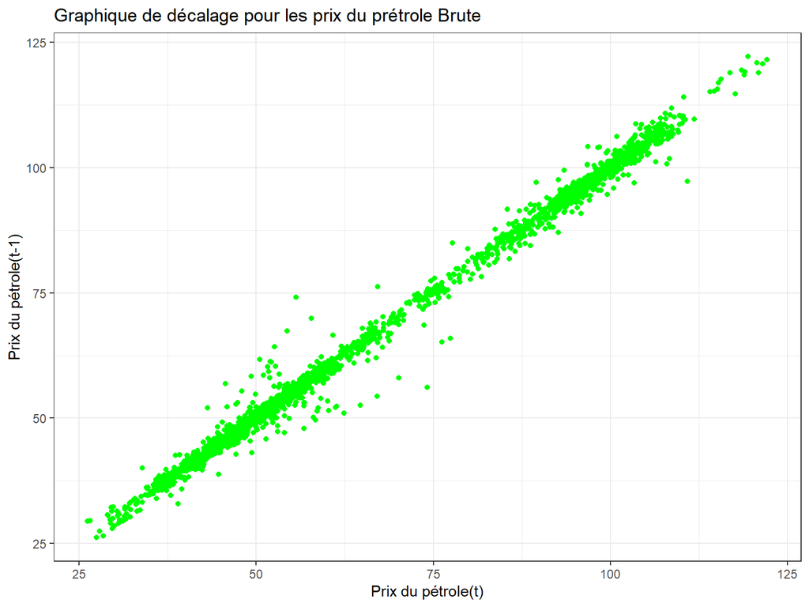

```r
# Créez un graphique de décalage du prétrole Brute
ggplot(df, aes(x = Crude.Oil, y = lag(Crude.Oil, 1))) +
  geom_point(color="green") +
  labs(title = "Graphique de décalage pour les prix du prétrole Brute", x = "Prix du pétrole(t)", y = "Prix du pétrole(t-1)") +
  theme_bw()
```

Le graphique de la série chronologique indique clairement une sorte de relation entre les séries. La forme linéaire du diagramme de décalage suggère qu’un modèle AR est un meilleur choix. Nous ne voyons pas non plus de valeur aberrante dans les données. Données montrant ici un motif linéaire, indiquant la présence d’une auto-corrélation positive.

“Les séries chronologiques pour les données économiques sont généralement stochastiques ou ont une tendance qui n’est pas stationnaire, ce qui signifie que les données ont une unité racine”

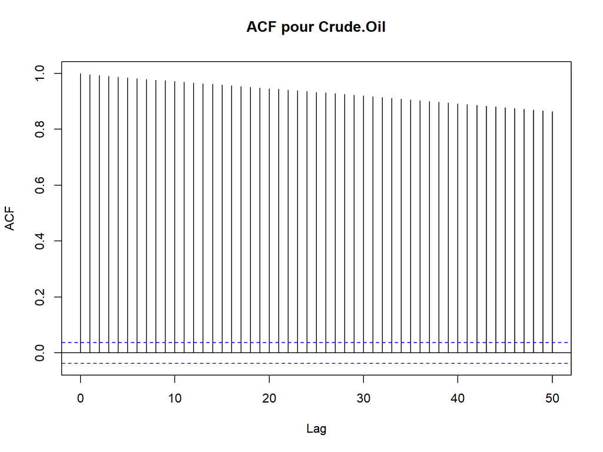

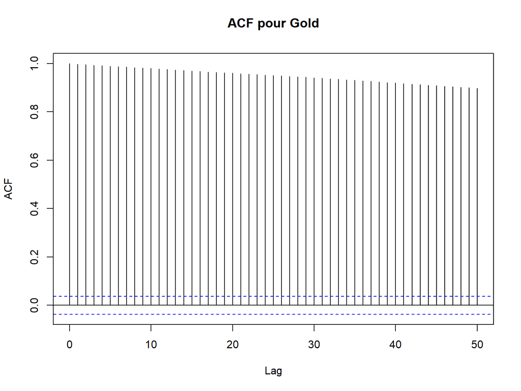

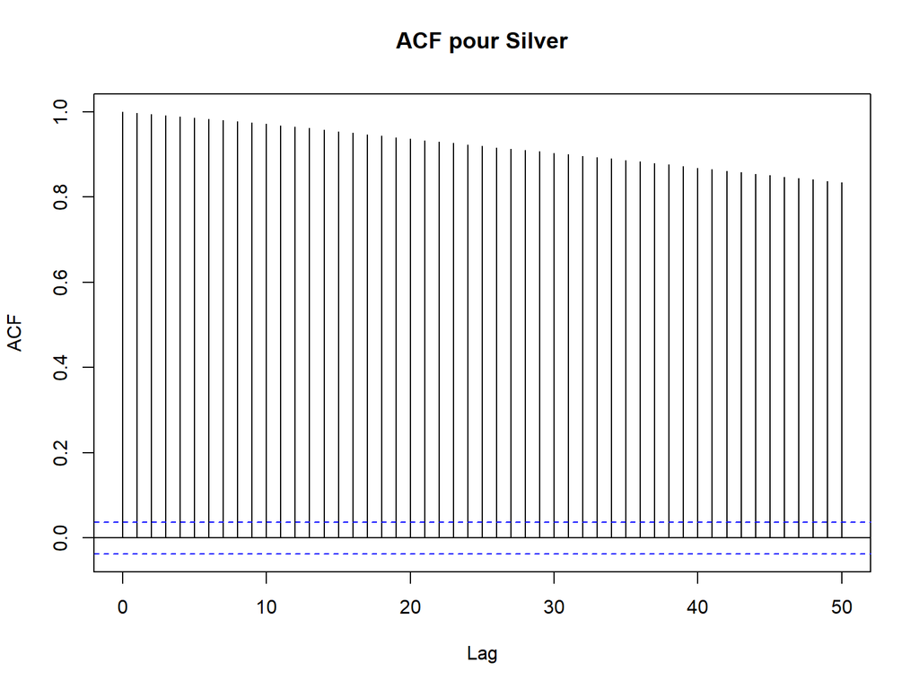

```r
# Affiche les graphiques d'autocorrélation pour chaque colonne du dataframe
for (i in names(df)[-1]) {
 acf(df[[i]], main = paste("ACF pour", i), lag.max = 50)
}
```

Ces graphiques montrent une autocorrélation forte en les séries considérés et leurs retards d’ordre h pour h allant de 1 à 50

```r
library(tseries)

adf.test(df$Crude.Oil)
```

```
##
##  Augmented Dickey-Fuller Test
##
## data:  df$Crude.Oil
## Dickey-Fuller = -3.5581, Lag order = 13, p-value = 0.03668
## alternative hypothesis: stationary
```

```r
adf.test(df$Gold)
```

```
##
##  Augmented Dickey-Fuller Test
##
## data:  df$Gold
## Dickey-Fuller = -1.3578, Lag order = 13, p-value = 0.8502
## alternative hypothesis: stationary
```

```r
adf.test(df$Silver)
```

```
##
##  Augmented Dickey-Fuller Test
##
## data:  df$Silver
## Dickey-Fuller = -1.9126, Lag order = 13, p-value = 0.6153
## alternative hypothesis: stationary
```

Ces tests de stationnarité montre que seule la série Croid.oil est stationnaire. Nous passons ainsi a la différentiation des deux autres séries

```r
  df_Gold = diff(df$Gold)
  df_silver = diff(df$Silver)
  adf.test(df_Gold)
```

```
##
##  Augmented Dickey-Fuller Test
##
## data:  df_Gold
## Dickey-Fuller = -14.064, Lag order = 13, p-value = 0.01
## alternative hypothesis: stationary
```

```r
  adf.test(df_silver)
```

```
##
##  Augmented Dickey-Fuller Test
##
## data:  df_silver
## Dickey-Fuller = -13.11, Lag order = 13, p-value = 0.01
## alternative hypothesis: stationary
```

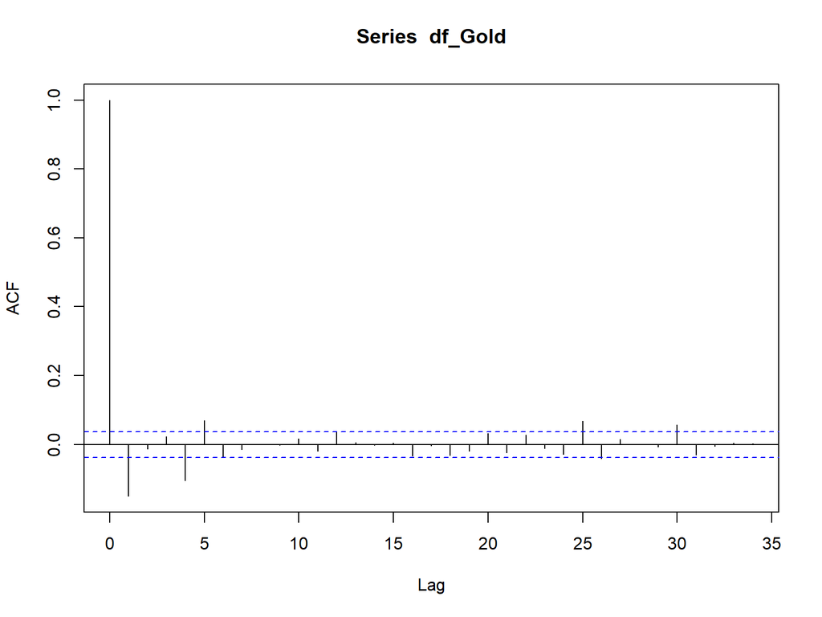

```r
  acf(df_Gold)
```

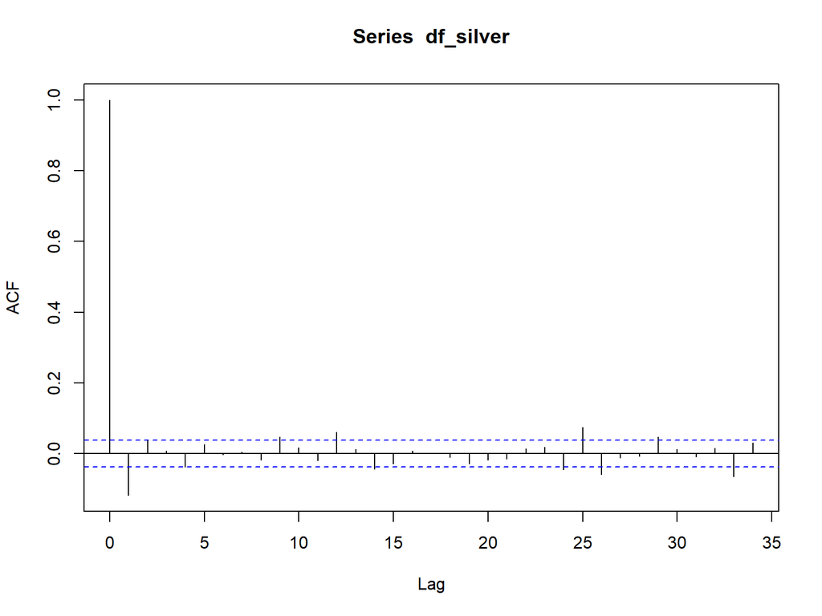

```r
  acf(df_silver)
```

Après différentiation d’ordre 1,nous obtenons des séries stationnaires car la p-value du test de stationnarité précédent < 0.05

# Analyse multivariée

### Selection de l’ordre de retard optimal

```r
  library(vars)
  data_matrix <- cbind(df$Crude.Oil[-1], df_Gold, df_silver)
  lag_selection <- VARselect(data_matrix, lag.max = 15, type = "none")$selection
  print(lag_selection)
```

```
## AIC(n)  HQ(n)  SC(n) FPE(n)
##      5      4      4      5
```

On choisit le lag optimal = 5

Nous allons maintenant vérifier les tests de causalité multivariée de Granger réalisée en ajustant un VAR à la série chronologique. Considérant ci-dessous une série chronologique multidimensionnelle multivariée

$$X(t) \in \mathbb{R}^{d+1} \text{ pour
}t=1,\dots,T$$
La causalité de Granger est effectuée en ajustant un modèle VAR avec L délais comme suit:
$$X(t) = \sum_{\tau=1}^LA_\tau X(t-\tau)+\epsilon(t)$$
où $\epsilon(t)$ est un vecteur aléatoire gaussien blanc, et $A_\tau$ est une matrice pour tout $\tau$. Une série temporelle $X_i$ est appelée cause de Granger d’une autre série temporelle $X_j$, si au moins un des éléments $A_\tau(j,i)$ pour $\tau = 1,\dots,L$ est significativement plus grand que zéro.

Rappel: - 1 : Crude Oil - 2 : Gold - 3 : Silver

```r
library(lmtest)

grangertest(df$Crude.Oil[-1] ~ df_Gold, order = 5)
```

```
## Granger causality test
##
## Model 1: df$Crude.Oil[-1] ~ Lags(df$Crude.Oil[-1], 1:5) + Lags(df_Gold, 1:5)
## Model 2: df$Crude.Oil[-1] ~ Lags(df$Crude.Oil[-1], 1:5)
##   Res.Df Df      F Pr(>F)
## 1   2715
## 2   2720 -5 0.6052  0.696
```

```r
grangertest(df_Gold ~ df$Crude.Oil[-1], order = 5)
```

```
## Granger causality test
##
## Model 1: df_Gold ~ Lags(df_Gold, 1:5) + Lags(df$Crude.Oil[-1], 1:5)
## Model 2: df_Gold ~ Lags(df_Gold, 1:5)
##   Res.Df Df      F Pr(>F)
## 1   2715
## 2   2720 -5 0.9364 0.4561
```

```r
grangertest(df$Crude.Oil[-1] ~ df_silver, order = 5)
```

```
## Granger causality test
##
## Model 1: df$Crude.Oil[-1] ~ Lags(df$Crude.Oil[-1], 1:5) + Lags(df_silver, 1:5)
## Model 2: df$Crude.Oil[-1] ~ Lags(df$Crude.Oil[-1], 1:5)
##   Res.Df Df      F Pr(>F)
## 1   2715
## 2   2720 -5 1.4534 0.2019
```

```r
grangertest(df_silver ~ df$Crude.Oil[-1], order = 5)
```

```
## Granger causality test
##
## Model 1: df_silver ~ Lags(df_silver, 1:5) + Lags(df$Crude.Oil[-1], 1:5)
## Model 2: df_silver ~ Lags(df_silver, 1:5)
##   Res.Df Df      F Pr(>F)
## 1   2715
## 2   2720 -5 0.6483 0.6629
```

```r
grangertest(df_silver ~ df_Gold, order = 5)
```

```
## Granger causality test
##
## Model 1: df_silver ~ Lags(df_silver, 1:5) + Lags(df_Gold, 1:5)
## Model 2: df_silver ~ Lags(df_silver, 1:5)
##   Res.Df Df     F  Pr(>F)
## 1   2715
## 2   2720 -5 2.798 0.01585 *
## ---
## Signif. codes:  0 '***' 0.001 '**' 0.01 '*' 0.05 '.' 0.1 ' ' 1
```

```r
grangertest(df_Gold ~ df_silver, order = 5)
```

```
## Granger causality test
##
## Model 1: df_Gold ~ Lags(df_Gold, 1:5) + Lags(df_silver, 1:5)
## Model 2: df_Gold ~ Lags(df_Gold, 1:5)
##   Res.Df Df     F    Pr(>F)
## 1   2715
## 2   2720 -5 12.61 3.943e-12 ***
## ---
## Signif. codes:  0 '***' 0.001 '**' 0.01 '*' 0.05 '.' 0.1 ' ' 1
```

Seul les 2 derniers tests effectués sont significatifs. On déduit que les séries Gold et Silver se causent.Nous retenons alors ces deux séries pour continuer l’étude. Nos séries sont bien causales. Nous devons ensuite vérifier s’il y a cointégration entre elles

# Test de cointégration de Johansen

Nous effectuons ici le test de cointégration de Johansen pour vérifier s’il existe éventuellement une relation de cointégration entre les deux séries. Il faut noter que ce test est capital avant de modéliser les données avec un VAR.

```r
  library(urca)
  data_matrix <- data.frame(df$Gold, df$Silver)
  johansen_test <- ca.jo(data_matrix, type = "trace", K = 2)
  summary(johansen_test)
```

```
##
## ######################
## # Johansen-Procedure #
## ######################
##
## Test type: trace statistic , with linear trend
##
## Eigenvalues (lambda):
## [1] 0.002374524 0.001007963
##
## Values of teststatistic and critical values of test:
##
##          test 10pct  5pct  1pct
## r <= 1 | 2.75  6.50  8.18 11.65
## r = 0  | 9.24 15.66 17.95 23.52
##
## Eigenvectors, normalised to first column:
## (These are the cointegration relations)
##
##              df.Gold.l2 df.Silver.l2
## df.Gold.l2      1.00000       1.0000
## df.Silver.l2  -39.80848     192.2444
##
## Weights W:
## (This is the loading matrix)
##
##                df.Gold.l2  df.Silver.l2
## df.Gold.d   -0.0046688621 -1.345947e-04
## df.Silver.d -0.0000469836 -9.245970e-06
```

Ce test montre l’absence d’une cointégration entre les deux séries. Les deux séries sont I(1) et leur résidu n’est pas T(0).

```r
library(dynlm)
cointcy <- dynlm(df$Gold~df$Silver, data=data_matrix)
ehat <- resid(cointcy)
adf.test(ehat)
```

```
##
##  Augmented Dickey-Fuller Test
##
## data:  ehat
## Dickey-Fuller = -2.6246, Lag order = 13, p-value = 0.3139
## alternative hypothesis: stationary
```

Le test de Dickey-Fuller vient confirmer les résultats du test de Johansen. L’absence de la relation de cointégration nous conduit a estimer un modèle VAR en différence

# Divisez la série en données d’entrainement et de test

```r
new_data = data.frame(df_Gold,df_silver)
row.names(new_data)<-df$Date[-length(df$Date)]
#new_data = new_data[-1] # Supprimons Crude Oil car déjà stationnaire

# Définir le nombre d'observations
n_obs <- 10

# Diviser les données en ensembles d'entraînement et de test
X_train <- new_data[1:(nrow(new_data) - n_obs),]
X_test <- new_data[(nrow(new_data) - n_obs + 1):nrow(new_data), ]

# Vérifier la taille des ensembles d'entraînement et de test
print(dim(X_train))
```

```
## [1] 2721    2
```

```r
print(dim(X_test))
```

```
## [1] 10  2
```

# Création d’un model VAR

```r
# Fit the VAR model with the selected lag order
model_fit <- VAR(X_train, p = 5)
summary(model_fit)
```

```
##
## VAR Estimation Results:
## =========================
## Endogenous variables: df_Gold, df_silver
## Deterministic variables: const
## Sample size: 2716
## Log Likelihood: -12001.179
## Roots of the characteristic polynomial:
## 0.7124 0.7124 0.6052 0.6052 0.535 0.535 0.4287 0.4279 0.4279 0.2623
## Call:
## VAR(y = X_train, p = 5)
##
##
## Estimation results for equation df_Gold:
## ========================================
## df_Gold = df_Gold.l1 + df_silver.l1 + df_Gold.l2 + df_silver.l2 + df_Gold.l3 + df_silver.l3 + df_Gold.l4 + df_silver.l4 + df_Gold.l5 + df_silver.l5 + const
##
##              Estimate Std. Error t value Pr(>|t|)
## df_Gold.l1   -0.26326    0.02609 -10.089  < 2e-16 ***
## df_silver.l1  6.80068    1.14617   5.933 3.35e-09 ***
## df_Gold.l2   -0.14225    0.02702  -5.265 1.52e-07 ***
## df_silver.l2  5.81502    1.18895   4.891 1.06e-06 ***
## df_Gold.l3   -0.06427    0.02713  -2.369  0.01793 *
## df_silver.l3  3.43869    1.19516   2.877  0.00404 **
## df_Gold.l4   -0.15439    0.02701  -5.715 1.21e-08 ***
## df_silver.l4  3.61979    1.19598   3.027  0.00250 **
## df_Gold.l5    0.05223    0.02607   2.003  0.04522 *
## df_silver.l5 -1.41026    1.15927  -1.217  0.22390
## const        -0.17760    0.32806  -0.541  0.58831
## ---
## Signif. codes:  0 '***' 0.001 '**' 0.01 '*' 0.05 '.' 0.1 ' ' 1
##
##
## Residual standard error: 17.08 on 2705 degrees of freedom
## Multiple R-Squared: 0.058,   Adjusted R-squared: 0.05452
## F-statistic: 16.65 on 10 and 2705 DF,  p-value: < 2.2e-16
##
##
## Estimation results for equation df_silver:
## ==========================================
```

[output cut: 18 more lines]

```
## Residual standard error: 0.3888 on 2705 degrees of freedom
## Multiple R-Squared: 0.0211,  Adjusted R-squared: 0.01748
## F-statistic:  5.83 on 10 and 2705 DF,  p-value: 9.549e-09
##
##
##
## Covariance matrix of residuals:
##           df_Gold df_silver
## df_Gold   291.576    4.5021
## df_silver   4.502    0.1511
##
## Correlation matrix of residuals:
##           df_Gold df_silver
## df_Gold    1.0000    0.6782
## df_silver  0.6782    1.0000
```

# Diagnostics du modèle

```r
  serial.test(model_fit, lags.pt = 16, type = "PT.asymptotic")
```

```
##
##  Portmanteau Test (asymptotic)
##
## data:  Residuals of VAR object model_fit
## Chi-squared = 68.7, df = 44, p-value = 0.01002
```

```r
  # Extraire les résidus du modèle VAR
  residuals <- residuals(model_fit)

  # Tester les autocorrélations des résidus pour chaque équation
  ljung_box_test1 <- Box.test(residuals[, 1], lag = 13, type = "Ljung-Box")
  ljung_box_test2 <- Box.test(residuals[, 2], lag = 13, type = "Ljung-Box")

  # Afficher les résultats des tests
  print(ljung_box_test1)
```

```
##
##  Box-Ljung test
##
## data:  residuals[, 1]
## X-squared = 8.3633, df = 13, p-value = 0.8192
```

```r
  print(ljung_box_test2)
```

```
##
##  Box-Ljung test
##
## data:  residuals[, 2]
## X-squared = 22.437, df = 13, p-value = 0.04895
```

```r
  library(car)
  dw_test_series1 <- durbinWatsonTest(residuals[, 1])
  dw_test_series2 <- durbinWatsonTest(residuals[, 2])

  # Afficher les résultats du test de Durbin-Watson
  print(dw_test_series1)
```

```
## [1] 1.997579
```

```r
  print(dw_test_series2)
```

```
## [1] 2.002593
```

Le test de portmanteau vectoriel permet de conclure a une présence d’autocorrélation entre les erreurs.Cependant les tests de Ljung-Box et de Durbin-Watson nous permet de considérer une absence d’autocorrélation entre les erreurs de la 1ère regression.La relation Silver~Gold se trouve non bien expliqué par le modèle Nous allons laisser tomber les tests de normalité des erreurs et de d’homoscédasticité qui sont de peu d’intérêt. Les prévisions sont générées sur les données d’entraînement utilisées par le modèle.

```r
# Get the lag order
lag_order <- model_fit$p
print(lag_order)
```

```
## [1] 5
```

```r
# Input data for forecasting
input_data <- tail(X_train, lag_order)
print(input_data)
```

```
##            df_Gold df_silver
## 2012-01-25   -35.6    -1.161
## 2012-01-24    13.8     0.302
## 2012-01-23   -14.3    -0.586
## 2012-01-20    -9.6    -1.165
## 2012-01-19     5.4     0.032
```

```r
# Forecasting
nobs = 10
pred <- predict(model_fit, n.ahead = nobs, newdata = input_data)
pred.value = pred$fcst
forecast_values_matrix <- do.call(cbind, lapply(pred.value, function(x) x[, "fcst"]))
print(forecast_values_matrix)
```

```
##            df_Gold    df_silver
##  [1,] -9.146060725 -0.104333080
##  [2,] -2.069018670 -0.011406015
##  [3,] -1.908593822 -0.003803944
##  [4,]  1.179683367 -0.041453810
##  [5,]  0.844367175  0.020872387
##  [6,] -0.609667469  0.002782082
##  [7,] -0.026368631  0.003446187
##  [8,] -0.453317792  0.002926204
##  [9,]  0.099457554 -0.000812780
## [10,]  0.004603235  0.004918673
```

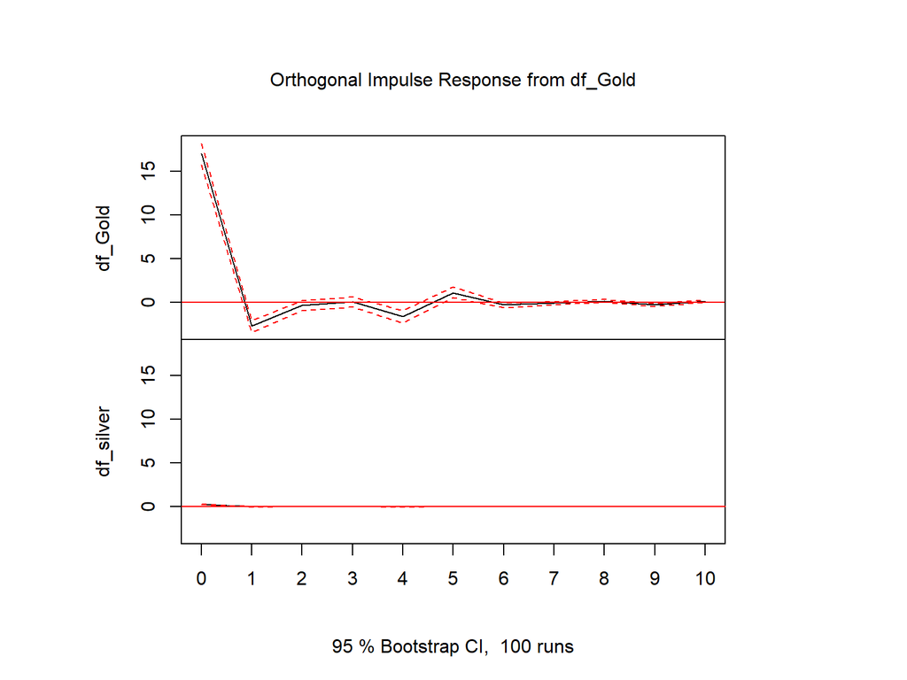

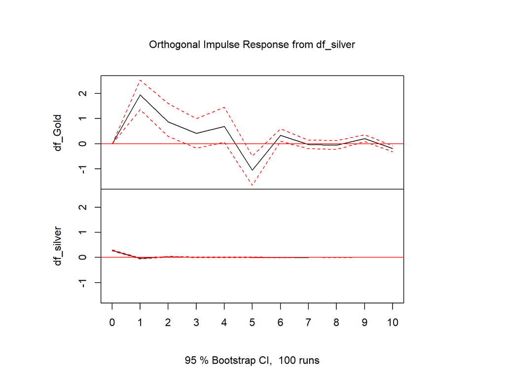

```r
  impresp <- irf(model_fit)
  plot(impresp)
```

L’interprétation des figures est simple : une impulsion (choc) pour df_silver au temps zéro a de petits effets la période suivante, effets qui deviennent de plus en plus petits au fur et à mesure que le temps passe.

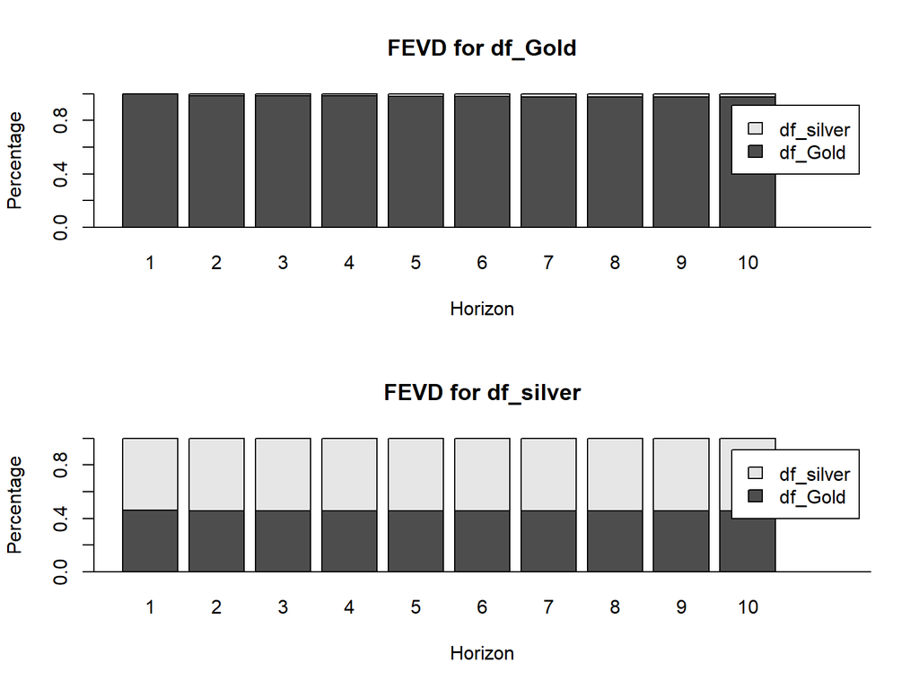

```r
plot(fevd(model_fit))
```

La décomposition de la variance prévue estime la contribution d’un choc dans chaque variable à la réponse dans les deux variables. La figure montre que près de 100 % de la variance de df_Goldest causée par df_Gold lui-même, alors que seulement environ 50 pour cent dans la variance de df_silver est causée par Dy et le reste est causé par df_silver.

# Estimation et analyse VECM

VECM impose une restriction supplémentaire en raison de l’existence de formulaires de données non stationnaires mais co-intégrés. Il utilise les informations de restriction de co-intégration dans ses spécifications. Une fois que la cointégration est connue, le processus de test suivant est effectué en utilisant la méthode de correction d’erreur. Grâce à VECM, nous pouvons interpréter des équations à long terme et à court terme. Nous devons déterminer le nombre de relations de co-intégration. L’avantage de VECM par rapport à VAR est que le VAR résultant de la représentation VECM a des estimations de coefficients plus efficaces.

### Data

```r
  library(urca)  # ca.jo, ur.df, finland
  library(vars)  # vec2var
  library(tsDyn) # VECM
  data(finland)

  start_date = as.Date("1958-01-01")
  end_date = as.Date("1984-06-30")

  # Créer une séquence trimestrielle
  dates = seq(from = start_date, to = end_date, by = "quarter")
  finland$date <- dates
  # Réorganiser les colonnes pour que 'date' soit la première colonne
  data <- finland
```

```r
  # Affichage des premières lignes
  head(data)
```

```
##       lrm1      lny       lnmr       difp       date
## 1 2.848664 3.836539 0.17311260 0.01481509 1958-01-01
## 2 2.828010 3.902982 0.10120190 0.00000000 1958-04-01
## 3 2.908186 3.896880 0.13208030 0.00000000 1958-07-01
## 4 2.934326 3.847045 0.06999237 0.00000000 1958-10-01
## 5 2.986127 3.916454 0.06531947 0.00000000 1959-01-01
## 6 3.006543 3.986216 0.06531947 0.01459880 1959-04-01
```

```r
  # Affichage des dernières lignes
  tail(data)
```

```
##         lrm1      lny      lnmr        difp       date
## 101 3.863014 4.923077 0.1397619 0.037234720 1983-01-01
## 102 3.852309 4.935910 0.1445332 0.012623350 1983-04-01
## 103 3.826078 4.980688 0.1551216 0.027351390 1983-07-01
## 104 3.782735 4.866376 0.1612681 0.004273511 1983-10-01
## 105 3.830368 4.959666 0.1544364 0.019007960 1984-01-01
## 106 3.825409 4.952320 0.1516905 0.014538160 1984-04-01
```

```r
str(data)
```

```
## 'data.frame':    106 obs. of  5 variables:
##  $ lrm1: num  2.85 2.83 2.91 2.93 2.99 ...
##  $ lny : num  3.84 3.9 3.9 3.85 3.92 ...
##  $ lnmr: num  0.1731 0.1012 0.1321 0.07 0.0653 ...
##  $ difp: num  0.0148 0 0 0 0 ...
##  $ date: Date, format: "1958-01-01" "1958-04-01" ...
```

Nous allons visualiser les données

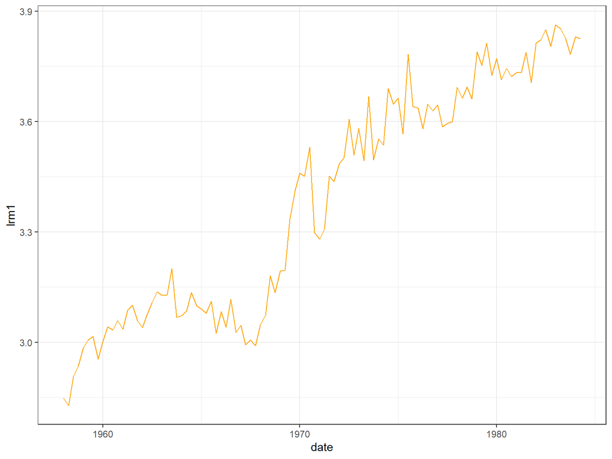

```r
  # Tracer les séries temporelles
ggplot(data, aes(x = date, y = lrm1)) +
  geom_line(color="orange")  +
  labs(X="Date", Y="lrm1") +
  theme_bw()
```

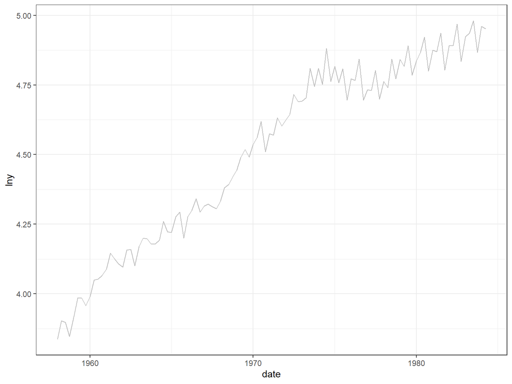

```r
ggplot(data, aes(x = date, y = lny)) +
  geom_line(color="grey") +
  labs(X="Date", Y="lny") +
  theme_bw()
```

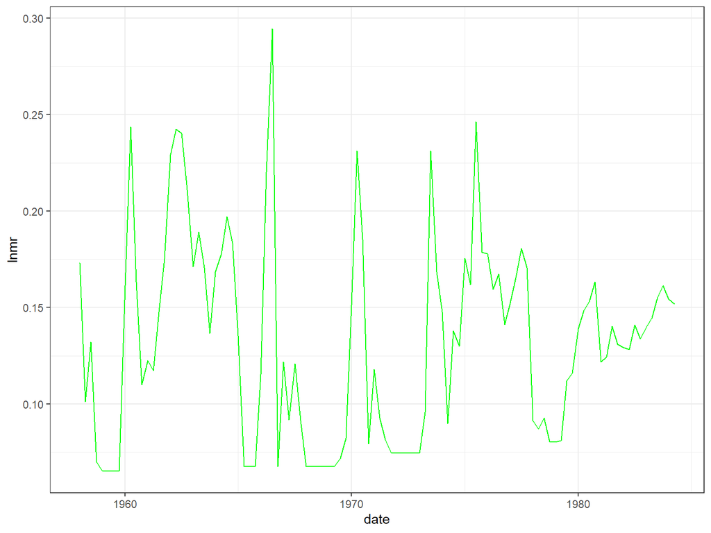

```r
ggplot(data, aes(x = date, y = lnmr)) +
  geom_line(color="green") +
  labs(X="Date", Y="lnmr") +
  theme_bw()
```

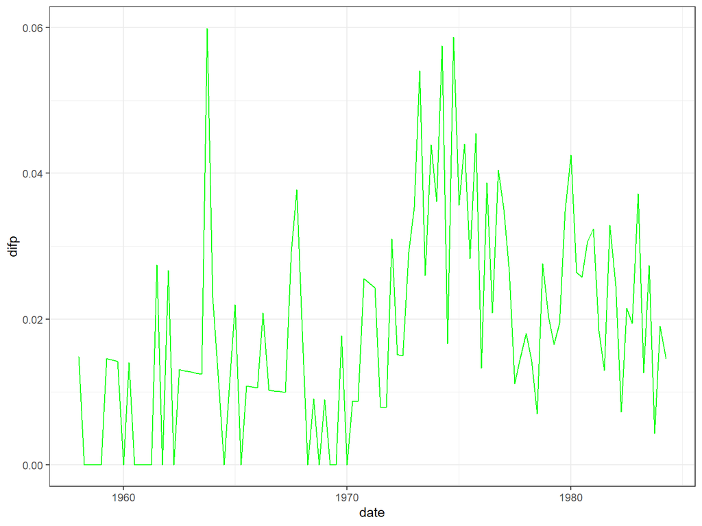

```r
ggplot(data, aes(x = date, y = difp)) +
  geom_line(color="green") +
  labs(X="Date", Y="difp") +
  theme_bw()
```

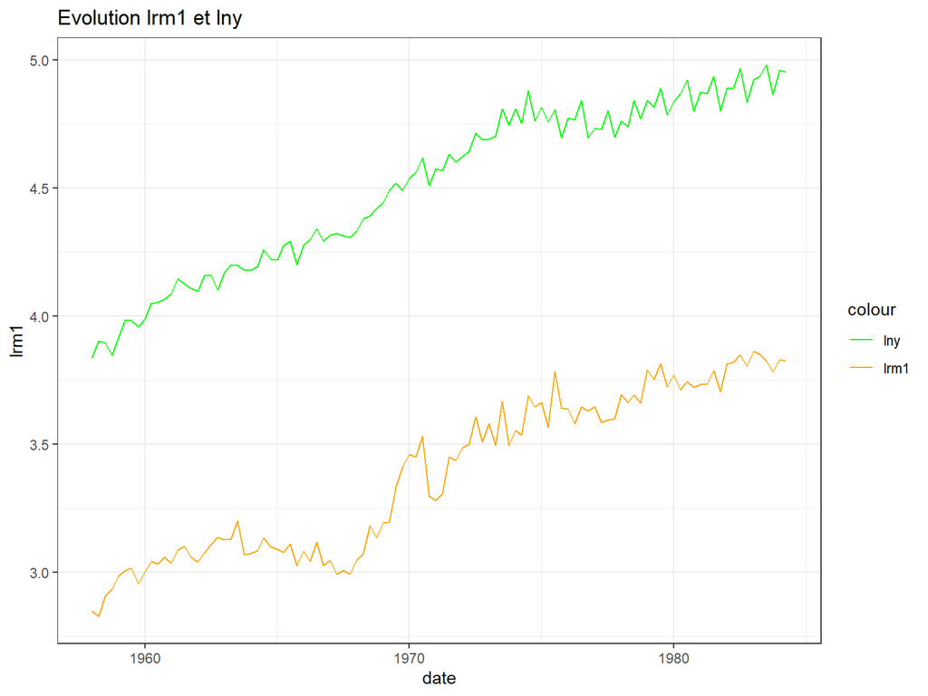

```r
# Mise en Commun
ggplot(data, aes(x=date))+
  geom_line(aes(y = lrm1, color = "lrm1")) +
  geom_line(aes(y = lny, color = "lny")) +
  labs( title = "Evolution lrm1 et lny") +
  scale_color_manual(values = c("lrm1" = "orange", "lny" = "green")) +
  theme_bw()
```

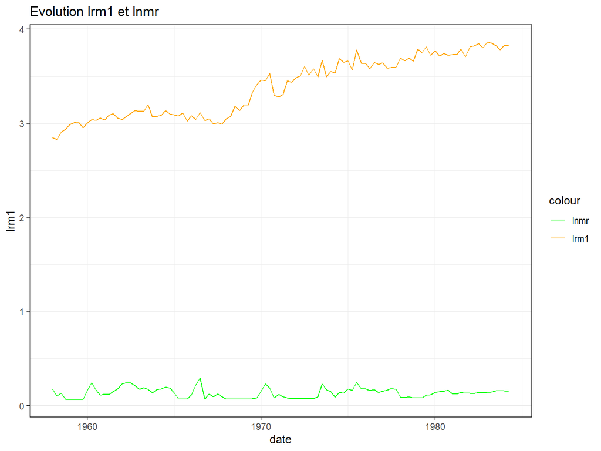

```r
ggplot(data, aes(x=date))+
  geom_line(aes(y = lrm1, color = "lrm1")) +
  geom_line(aes(y = lnmr, color = "lnmr")) +
  labs( title = "Evolution lrm1 et lnmr") +
  scale_color_manual(values = c("lrm1" = "orange", "lnmr" = "green")) +
  theme_bw()
```

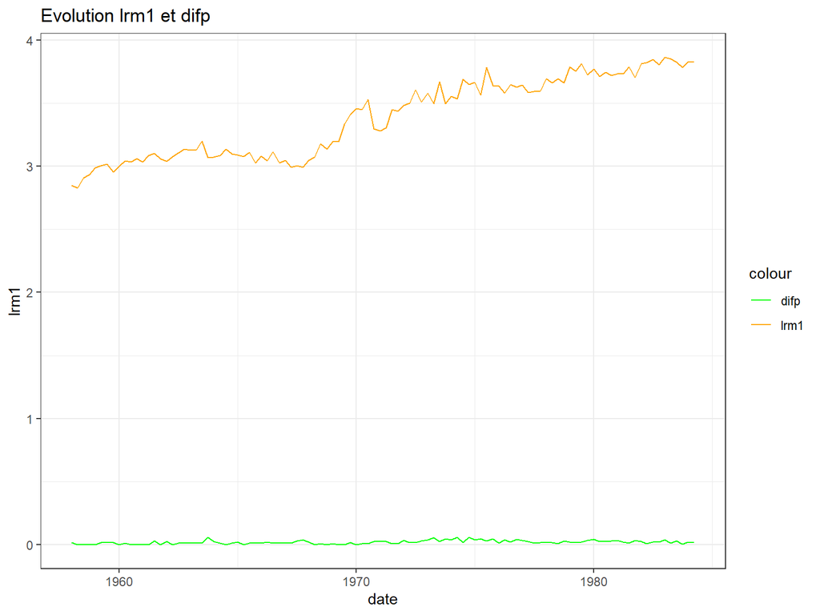

```r
ggplot(data, aes(x=date))+
  geom_line(aes(y = lrm1, color = "lrm1")) +
  geom_line(aes(y = difp, color = "difp")) +
  labs( title = "Evolution lrm1 et difp") +
  scale_color_manual(values = c("lrm1" = "orange", "difp" = "green")) +
  theme_bw()
```

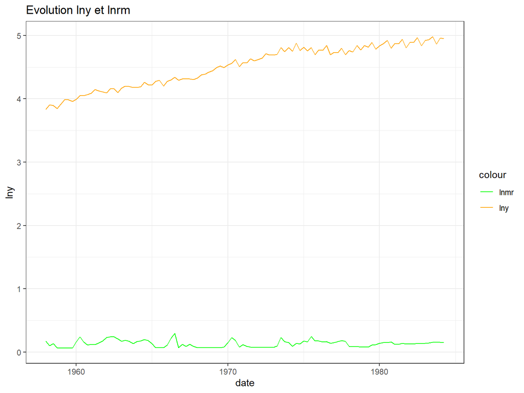

```r
ggplot(data, aes(x=date))+
  geom_line(aes(y = lny, color = "lny")) +
  geom_line(aes(y = lnmr, color = "lnmr")) +
  labs( title = "Evolution lny et lnrm") +
  scale_color_manual(values = c("lny" = "orange", "lnmr" = "green")) +
  theme_bw()
```

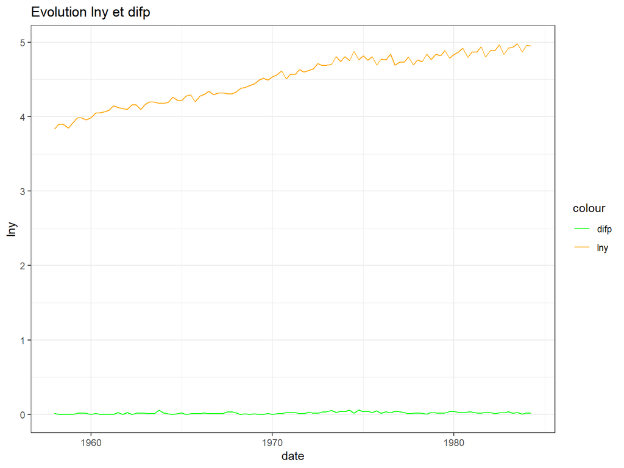

```r
ggplot(data, aes(x=date))+
  geom_line(aes(y = lny, color = "lny")) +
  geom_line(aes(y = difp, color = "difp")) +
  labs( title = "Evolution lny et difp") +
  scale_color_manual(values = c("lny" = "orange", "difp" = "green")) +
  theme_bw()
```

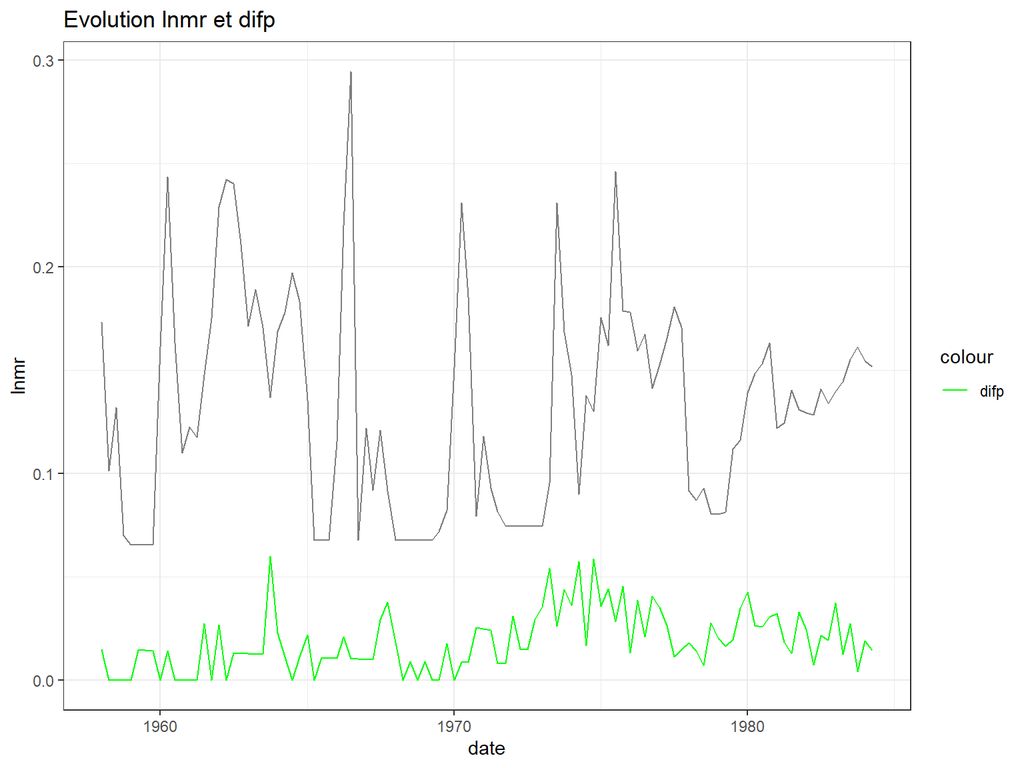

```r
ggplot(data, aes(x=date))+
  geom_line(aes(y = lnmr, color = "lnmr")) +
  geom_line(aes(y = difp, color = "difp")) +
  labs( title = "Evolution lnmr et difp") +
  scale_color_manual(values = c("lrmr" = "orange", "difp" = "green")) +
  theme_bw()
```

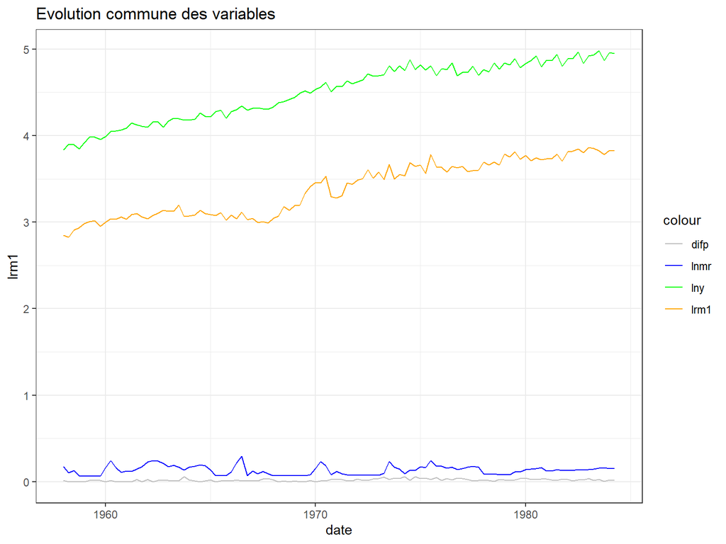

```r
ggplot(data, aes(x=date))+
  geom_line(aes(y = lrm1, color = "lrm1")) +
  geom_line(aes(y = lny, color = "lny")) +
  geom_line(aes(y = lnmr, color = "lnmr")) +
  geom_line(aes(y = difp, color = "difp")) +
  labs( title = "Evolution commune des variables") +
  scale_color_manual(values = c("lrm1" = "orange", "lny" = "green", "lnmr" = "blue", "difp" = "grey")) +
  theme_bw()
```